# Lab 7 Assignment by Group 25

| Student IDs | Names |
| --- | --- |
| s154146 | Andreas Høyer Kongsgaard |
| s221047 | Darya Trubach |
| s194360 | Emilie Sofie Engdal |
| s230705 | Jennifer Fortuny I Zhan |
| s215112 | Manon Kirstine Chevalier |

# Background

Principal Component Analysis (PCA) is a widely-used technique in statistics and machine learning for dimensionality reduction and data visualisation. It aims to transform the original set of correlated variables into a new set of uncorrelated variables, known as principal components, which capture most of the variability in the data.

In the realm of data analysis using R, the tidyverse package is often considered a go-to tool. It offers a cohesive set of packages for data manipulation, exploration, and visualisation in a “tidy” data format. Combining PCA with the tidyverse style of coding provides an intuitive and efficient approach to data analysis.

Professor Claus O. Wilke has demonstrated the implementation of PCA in a tidyverse style through a comprehensive post. This micro-report aims to perform a code-along with the data and methodology presented in Professor Wilke’s post. Alternatively, this exercise can also be replicated using the Gravier dataset or other datasets to compare and contrast the efficacy and insights gathered through this approach.

# PCA tidyverse style

For our PCA example, we’ll need the packages tidyverse and broom. Note that as of this writing, we need the current development version of broom [because of a bug](https://github.com/tidymodels/broom/issues/923) in `tidy.prcomp()`. We’ll also use the cowplot package for plot themes.

## Loading libraries

```r
library(tidyverse)
# ── Attaching packages ────────────────────────────────── tidyverse 1.3.0 ──
# ✓ ggplot2 3.3.2     ✓ purrr   0.3.4
# ✓ tibble  3.0.3     ✓ dplyr   1.0.2
# ✓ tidyr   1.1.2     ✓ stringr 1.4.0
# ✓ readr   1.3.1     ✓ forcats 0.5.0
# ── Conflicts ───────────────────────────────────── tidyverse_conflicts() ──
# x dplyr::filter() masks stats::filter()
# x dplyr::lag()    masks stats::lag()
library(broom)  # devtools::install_github("tidymodels/broom")
library(cowplot)
install.packages("ggrepel")
library(ggrepel)
library(ggplot2)
library(gridExtra)
library(tibble)
```

## Loading data

```r
biopsy <- read_csv("https://wilkelab.org/classes/SDS348/data_sets/biopsy.csv")
```

## Look at the data in PC coordinates

We start by running the PCA and storing the result in a variable `pca_fit`. There are two issues to consider here. First, the `prcomp()` function can only deal with numeric columns, so we need to remove all non-numeric columns from the data. This is straightforward using the `where(is.numeric)` tidyselect construct. Second, we normally want to scale the data values to unit variance before PCA. We do so by using the argument `scale = TRUE` in `prcomp()`.

```r
pca_fit <- biopsy %>%
  select(where(is.numeric)) %>% # retain only numeric columns
  prcomp(scale = TRUE) # do PCA on scaled data
```

As an alternative to `scale = TRUE`, we could also have scaled the data by explicitly invoking the `scale()` function.

```r
pca_fit <- biopsy %>%
  select(where(is.numeric)) %>% # retain only numeric columns
  scale() %>% # scale data
  prcomp() # do PCA
```

Now, we want to plot the data in PC coordinates. In general, this means combining the PC coordinates with the original dataset, so we can color points by categorical variables present in the original data but removed for the PCA. We do this with the `augment()` function from broom, which takes as arguments the fitted model and the original data. The columns containing the fitted coordinates are called `.fittedPC1`, `.fittedPC2`, etc.

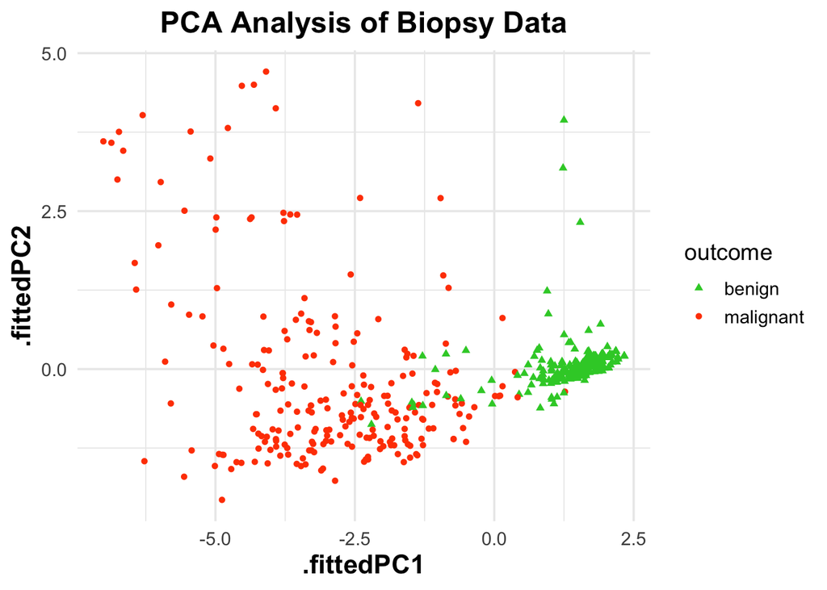

```r
pca_fit %>%
  augment(biopsy) %>% # add original dataset back in
  ggplot(aes(.fittedPC1, .fittedPC2, color = outcome)) +
  geom_point(size = 1.5, aes(shape = outcome), stroke = 0.5) +
  scale_color_manual(
    values = c(malignant = "#FF4500", benign = "#32CD32")) +
  scale_shape_manual(
    values = c(malignant = 16, benign = 17) # Different shapes for each outcome
  ) +
  ggtitle("PCA Analysis of Biopsy Data") + # Adding a title
  theme_minimal(base_size = 14) + # A minimal and classy theme
  theme(
    axis.title.x = element_text(face = "bold", size = 16),
    axis.title.y = element_text(face = "bold", size = 16),
    plot.title = element_text(hjust = 0.5, face = "bold", size = 18)
  )
```

## Rotation Matrix

Look at the data in PC coordinates. Next, we plot the rotation matrix. The rotation matrix is stored as `pca_fit$rotation`, but here we’ll extract it using the `tidy()` function from broom. When applied to `prcomp` objects, the `tidy()` function takes an additional argument `matrix`, which we set to `matrix = "rotation"` to extract the rotation matrix.

```r
# extract rotation matrix
pca_fit %>%
  tidy(matrix = "rotation")
```

[output not shown]

## Now in the context of a plot:

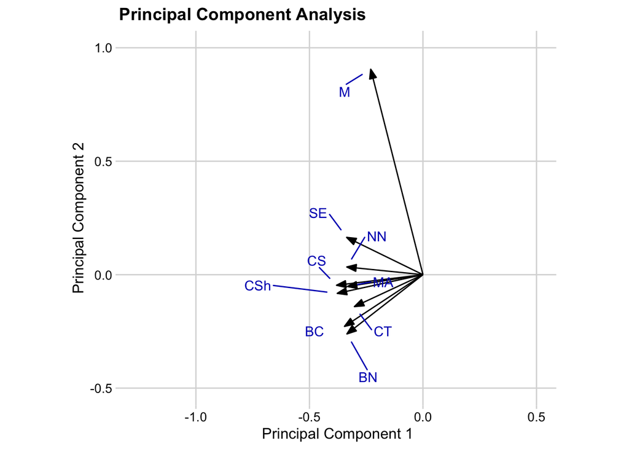

```r
# Prepare data with acronyms
rot_data <- pca_fit %>%
  tidy(matrix = "rotation") %>%
  pivot_wider(names_from = "PC", names_prefix = "PC", values_from = "value") %>%
  mutate(acronym = c("CT", "CS", "CSh", "MA", "SE", "BN", "BC", "NN", "M"))  # 9 acronyms for 9 rows

# Define arrow style for plotting
arrow_style <- arrow(
  angle = 20, ends = "first", type = "closed", length = grid::unit(8, "pt")
)

# Plotting
p <- rot_data %>%
  ggplot(aes(PC1, PC2)) +
  geom_segment(aes(xend = 0, yend = 0), arrow = arrow_style) +
  geom_text_repel(aes(label = acronym), box.padding = 1, point.padding = 1,
                  color = "#0000BF", max.overlaps = 50) +  # increased max.overlaps
  xlim(-1.25, .5) + ylim(-.5, 1) +
  coord_fixed() +
  theme_minimal_grid(12) +
  labs(title = "Principal Component Analysis",  # Added title
       x = "Principal Component 1", y = "Principal Component 2")

# Create a table of acronyms
acronym_table <- tibble(Acronym = c("CT", "CS", "CSh", "MA", "SE", "BN", "BC", "NN", "M"),
                        Description = c("Clump Thickness", "Cell Size", "Cell Shape", "Mitoses Activity",
                                        "Single Epithelial", "Bare Nuclei", "Bland Chromatin",
                                        "Normal Nuclei", "Mitoses"))

# Show the plot and the table
print(p)
```

```r
print(acronym_table)
```

```
# A tibble: 9 × 2
  Acronym Description
  <chr>   <chr>
1 CT      Clump Thickness
2 CS      Cell Size
3 CSh     Cell Shape
4 MA      Mitoses Activity
5 SE      Single Epithelial
6 BN      Bare Nuclei
7 BC      Bland Chromatin
8 NN      Normal Nuclei
9 M       Mitoses
```

## Look at the variance explained by each PC

Finally, we’ll plot the variance explained by each PC. We can again extract this information using the `tidy()` function from broom, now by setting the `matrix` argument to `matrix = "eigenvalues"`.

```r
pca_fit %>%
  tidy(matrix = "eigenvalues")
```

[output not shown]

## Now in the context of a plot.

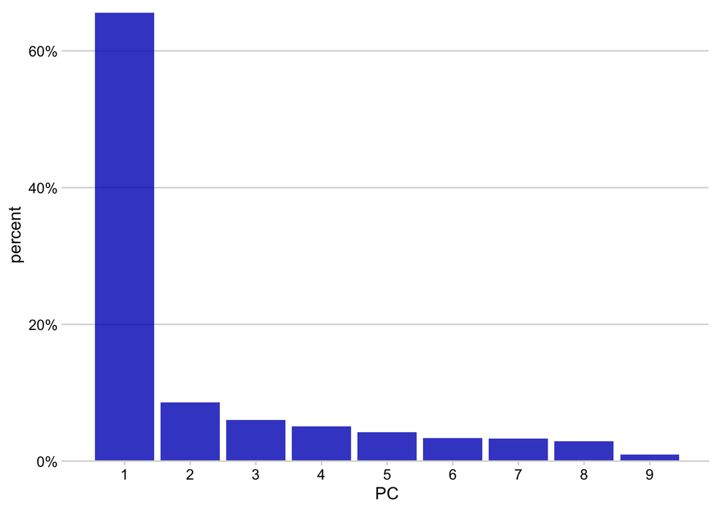

```r
pca_fit %>%
  tidy(matrix = "eigenvalues") %>%
  ggplot(aes(PC, percent)) +
  geom_col(fill = "#0000BF", alpha = 0.8) +
  scale_x_continuous(breaks = 1:9) +
  scale_y_continuous(
    labels = scales::percent_format(),
    expand = expansion(mult = c(0, 0.01))
  ) +
  theme_minimal_hgrid(12)
```

The first component captures 65% of the variation in the data and, as we can see from the first plot in this post, nicely separates the benign samples from the malignant samples.